# Travel Package Purchase Prediction

## Table of Contents

- Context
- Data Dictionary
- Problem
- Libraries
- Read and Understand Data
- Data Preprocessing
- Exploratory Data Analysis
- Insights based on EDA
- Missing value Detection and Treatment
- Outlier Detection
- Model Building
- Conclusion
- Business Recommendations & Insights

## Context

"Visit with us". company wants to enable and establish a viable business model to expand the customer base. One of the ways to expand the customer base is to introduce a new offering of packages. Currently, there are 5 types of packages the company is offering - Basic, Standard, Deluxe, Super Deluxe, King. Looking at the data of the last year, we observed that 18% of the customers purchased the packages. However, the marketing cost was quite high because customers were contacted at random without looking at the available information.The company is now planning to launch a new product i.e. Wellness Tourism Package. Wellness Tourism is defined as Travel that allows the traveler to maintain, enhance or kick-start a healthy lifestyle, and support or increase one's sense of well-being.However, this time company wants to harness the available data of existing and potential customers to make the marketing expenditure more efficient.

We need to analyze the customers' data and information to provide recommendations to the Policy Maker and Marketing Team and also build a model to predict the potential customer who is going to purchase the newly introduced travel package.

## Data Dictionary

Customer details:

- CustomerID: Unique customer ID
- ProdTaken: Whether the customer has purchased a package or not (0: No, 1: Yes)
- Age: Age of customer
- TypeofContact: How customer was contacted (Company Invited or Self Inquiry)
- CityTier: City tier depends on the development of a city, population, facilities, and living standards. The categories are ordered i.e. Tier 1 > Tier 2 > Tier 3
- Occupation: Occupation of customer
- Gender: Gender of customer
- NumberOfPersonVisiting: Total number of persons planning to take the trip with the customer
- PreferredPropertyStar: Preferred hotel property rating by customer
- MaritalStatus: Marital status of customer
- NumberOfTrips: Average number of trips in a year by customer
- Passport: The customer has a passport or not (0: No, 1: Yes)
- OwnCar: Whether the customers own a car or not (0: No, 1: Yes)
- NumberOfChildrenVisiting: Total number of children with age less than 5 planning to take the trip with the customer
- Designation: Designation of the customer in the current organization
- MonthlyIncome: Gross monthly income of the customer

Customer interaction data:

- PitchSatisfactionScore: Sales pitch satisfaction score
- ProductPitched: Product pitched by the salesperson
- NumberOfFollowups: Total number of follow-ups has been done by the salesperson after the sales pitch
- DurationOfPitch: Duration of the pitch by a salesperson to the customer

## Problem

- To predict which customer is more likely to purchase the newly introduced travel package
- Which variables are most significant.
- Which segment of customers should be targeted more.

## Libraries

```python
#To install xgboost library use -
!pip install xgboost
### IMPORT: ------------------------------------
import scipy.stats as stats
import pandas as pd
import numpy as np

import matplotlib.pyplot as plt
%matplotlib inline
import seaborn as sns
import warnings

import statsmodels.api as sm
#--Sklearn library--
from sklearn.model_selection import train_test_split # Sklearn package's randomized data splitting function

from sklearn import metrics

from sklearn.ensemble import BaggingClassifier,RandomForestClassifier,StackingClassifier
from sklearn.tree import DecisionTreeClassifier
from sklearn.ensemble import AdaBoostClassifier, GradientBoostingClassifier

from xgboost import XGBClassifier
from sklearn import tree
from sklearn.linear_model import LogisticRegression

# Libtune to tune model, get different metric scores

from sklearn.metrics import  classification_report, accuracy_score, precision_score, recall_score,f1_score
from sklearn.model_selection import GridSearchCV
from sklearn.metrics import confusion_matrix,ConfusionMatrixDisplay,plot_confusion_matrix #to plot confusion matric

pd.set_option('display.float_format', lambda x: '%.3f' % x)
pd.set_option('display.max_rows', 300)
pd.set_option('display.max_colwidth',400)
# To supress numerical display in scientific notations
pd.set_option('display.float_format', lambda x: '%.5f' % x)
warnings.filterwarnings('ignore') # To supress warnings
 # set the background for the graphs
plt.style.use('ggplot')
# For pandas profiling
from pandas_profiling import ProfileReport
print('Load Libraries-Done')
#!pip install xlrd
#!!pip install openpyxl
```

```
Load Libraries-Done
```

## Read and Understand Data

```python
#Reading the Excel file  used tourism.xlsx
data_path='travel.csv'

#Loading the dataset - sheet_name parameter is used if there are tabs in the excel file
#df=pd.read_excel(data_path,sheet_name='Tourism')
df=pd.read_csv(data_path)

df_tour=df.copy()
print(f'There are {df_tour.shape[0]} rows and {df_tour.shape[1]} columns') # fstring
```

```
There are 4888 rows and 20 columns
```

#### View the first and last 5 rows of the dataset.

```python
df_tour.head()
```

|  | CustomerID | ProdTaken | Age | TypeofContact | CityTier | DurationOfPitch | Occupation | Gender | NumberOfPersonVisiting | NumberOfFollowups | ProductPitched | PreferredPropertyStar | MaritalStatus | NumberOfTrips | Passport | PitchSatisfactionScore | OwnCar | NumberOfChildrenVisiting | Designation | MonthlyIncome |
| --- | --- | --- | --- | --- | --- | --- | --- | --- | --- | --- | --- | --- | --- | --- | --- | --- | --- | --- | --- | --- |
| 0 | 200000 | 1 | 41.00000 | Self Enquiry | 3 | 6.00000 | Salaried | Female | 3 | 3.00000 | Deluxe | 3.00000 | Single | 1.00000 | 1 | 2 | 1 | 0.00000 | Manager | 20993.00000 |
| 1 | 200001 | 0 | 49.00000 | Company Invited | 1 | 14.00000 | Salaried | Male | 3 | 4.00000 | Deluxe | 4.00000 | Divorced | 2.00000 | 0 | 3 | 1 | 2.00000 | Manager | 20130.00000 |
| 2 | 200002 | 1 | 37.00000 | Self Enquiry | 1 | 8.00000 | Free Lancer | Male | 3 | 4.00000 | Basic | 3.00000 | Single | 7.00000 | 1 | 3 | 0 | 0.00000 | Executive | 17090.00000 |
| 3 | 200003 | 0 | 33.00000 | Company Invited | 1 | 9.00000 | Salaried | Female | 2 | 3.00000 | Basic | 3.00000 | Divorced | 2.00000 | 1 | 5 | 1 | 1.00000 | Executive | 17909.00000 |
| 4 | 200004 | 0 | NaN | Self Enquiry | 1 | 8.00000 | Small Business | Male | 2 | 3.00000 | Basic | 4.00000 | Divorced | 1.00000 | 0 | 5 | 1 | 0.00000 | Executive | 18468.00000 |

```python
df_tour.tail()
```

|  | CustomerID | ProdTaken | Age | TypeofContact | CityTier | DurationOfPitch | Occupation | Gender | NumberOfPersonVisiting | NumberOfFollowups | ProductPitched | PreferredPropertyStar | MaritalStatus | NumberOfTrips | Passport | PitchSatisfactionScore | OwnCar | NumberOfChildrenVisiting | Designation | MonthlyIncome |
| --- | --- | --- | --- | --- | --- | --- | --- | --- | --- | --- | --- | --- | --- | --- | --- | --- | --- | --- | --- | --- |
| 4883 | 204883 | 1 | 49.00000 | Self Enquiry | 3 | 9.00000 | Small Business | Male | 3 | 5.00000 | Deluxe | 4.00000 | Unmarried | 2.00000 | 1 | 1 | 1 | 1.00000 | Manager | 26576.00000 |
| 4884 | 204884 | 1 | 28.00000 | Company Invited | 1 | 31.00000 | Salaried | Male | 4 | 5.00000 | Basic | 3.00000 | Single | 3.00000 | 1 | 3 | 1 | 2.00000 | Executive | 21212.00000 |
| 4885 | 204885 | 1 | 52.00000 | Self Enquiry | 3 | 17.00000 | Salaried | Female | 4 | 4.00000 | Standard | 4.00000 | Married | 7.00000 | 0 | 1 | 1 | 3.00000 | Senior Manager | 31820.00000 |
| 4886 | 204886 | 1 | 19.00000 | Self Enquiry | 3 | 16.00000 | Small Business | Male | 3 | 4.00000 | Basic | 3.00000 | Single | 3.00000 | 0 | 5 | 0 | 2.00000 | Executive | 20289.00000 |
| 4887 | 204887 | 1 | 36.00000 | Self Enquiry | 1 | 14.00000 | Salaried | Male | 4 | 4.00000 | Basic | 4.00000 | Unmarried | 3.00000 | 1 | 3 | 1 | 2.00000 | Executive | 24041.00000 |

```python
#### Understand the  dataset.
#get the size of dataframe
print ("Rows     : " , df_tour.shape[0])  #get number of rows/observations
print ("Columns  : " , df_tour.shape[1]) #get number of columns
print ("#"*40,"\n","Features : \n\n", df_tour.columns.tolist()) #get name of columns/features
print ("#"*40,"\nMissing values :\n\n", df_tour.isnull().sum().sort_values(ascending=False))
print( "#"*40,"\nPercent of missing :\n\n", round(df_tour.isna().sum() / df_tour.isna().count() * 100, 2).sort_values(ascending=False)) # looking at columns with most Missing Values
```

```
Rows     :  4888
Columns  :  20
########################################
 Features :

 ['CustomerID', 'ProdTaken', 'Age', 'TypeofContact', 'CityTier', 'DurationOfPitch', 'Occupation', 'Gender', 'NumberOfPersonVisiting', 'NumberOfFollowups', 'ProductPitched', 'PreferredPropertyStar', 'MaritalStatus', 'NumberOfTrips', 'Passport', 'PitchSatisfactionScore', 'OwnCar', 'NumberOfChildrenVis…
########################################
Missing values :

 DurationOfPitch             251
MonthlyIncome               233
Age                         226
NumberOfTrips               140
NumberOfChildrenVisiting     66
NumberOfFollowups            45
PreferredPropertyStar        26
TypeofContact                25
Designation                   0
OwnCar                        0
PitchSatisfactionScore        0
Passport                      0
CustomerID                    0
MaritalStatus                 0
ProdTaken                     0
NumberOfPersonVisiting        0
Gender                        0
Occupation                    0
CityTier                      0
ProductPitched                0
dtype: int64
########################################
Percent of missing :

 DurationOfPitch            5.14000
MonthlyIncome              4.77000
Age                        4.62000
NumberOfTrips              2.86000
NumberOfChildrenVisiting   1.35000
NumberOfFollowups          0.92000
PreferredPropertyStar      0.53000
TypeofContact              0.51000
Designation                0.00000
OwnCar                     0.00000
PitchSatisfactionScore     0.00000
Passport                   0.00000
CustomerID                 0.00000
MaritalStatus              0.00000
ProdTaken                  0.00000
NumberOfPersonVisiting     0.00000
Gender                     0.00000
Occupation                 0.00000
CityTier                   0.00000
ProductPitched             0.00000
dtype: float64
```

```python
#### Check the data types of the columns for the dataset.
df_tour.info()
```

```
<class 'pandas.core.frame.DataFrame'>
RangeIndex: 4888 entries, 0 to 4887
Data columns (total 20 columns):
 #   Column                    Non-Null Count  Dtype
---  ------                    --------------  -----
 0   CustomerID                4888 non-null   int64
 1   ProdTaken                 4888 non-null   int64
 2   Age                       4662 non-null   float64
 3   TypeofContact             4863 non-null   object
 4   CityTier                  4888 non-null   int64
 5   DurationOfPitch           4637 non-null   float64
 6   Occupation                4888 non-null   object
 7   Gender                    4888 non-null   object
 8   NumberOfPersonVisiting    4888 non-null   int64
 9   NumberOfFollowups         4843 non-null   float64
 10  ProductPitched            4888 non-null   object
 11  PreferredPropertyStar     4862 non-null   float64
 12  MaritalStatus             4888 non-null   object
 13  NumberOfTrips             4748 non-null   float64
 14  Passport                  4888 non-null   int64
 15  PitchSatisfactionScore    4888 non-null   int64
 16  OwnCar                    4888 non-null   int64
 17  NumberOfChildrenVisiting  4822 non-null   float64
 18  Designation               4888 non-null   object
 19  MonthlyIncome             4655 non-null   float64
dtypes: float64(7), int64(7), object(6)
memory usage: 763.9+ KB
```

**Observations**

- There are lot of missing values.
- 5% values are missing in DurationOfPitch, that may be cause customer was never pitched, need to analyze further
- 4.77% values are missig from MonthlyIncome.
- Age has 4.62 % missing values.
- NumberOfChildrenVisiting,NumberOfFollowups,NumberOfTrips,PreferredPropertyStar,TypeofContact has less than 3% missing values
- ProdTaken is the Target Variable
- Designation,Martial status,Product Pitched,Gender,Owncar,Passport,CityTier,PreferredPropertyStar, Occupation,Type of Contact are categorical variables while others are numerical value.

```python
#### Summary of the dataset.
df_tour.describe().T
```

|  | count | mean | std | min | 25% | 50% | 75% | max |
| --- | --- | --- | --- | --- | --- | --- | --- | --- |
| CustomerID | 4888.00000 | 202443.50000 | 1411.18839 | 200000.00000 | 201221.75000 | 202443.50000 | 203665.25000 | 204887.00000 |
| ProdTaken | 4888.00000 | 0.18822 | 0.39092 | 0.00000 | 0.00000 | 0.00000 | 0.00000 | 1.00000 |
| Age | 4662.00000 | 37.62227 | 9.31639 | 18.00000 | 31.00000 | 36.00000 | 44.00000 | 61.00000 |
| CityTier | 4888.00000 | 1.65426 | 0.91658 | 1.00000 | 1.00000 | 1.00000 | 3.00000 | 3.00000 |
| DurationOfPitch | 4637.00000 | 15.49083 | 8.51964 | 5.00000 | 9.00000 | 13.00000 | 20.00000 | 127.00000 |
| NumberOfPersonVisiting | 4888.00000 | 2.90507 | 0.72489 | 1.00000 | 2.00000 | 3.00000 | 3.00000 | 5.00000 |
| NumberOfFollowups | 4843.00000 | 3.70845 | 1.00251 | 1.00000 | 3.00000 | 4.00000 | 4.00000 | 6.00000 |
| PreferredPropertyStar | 4862.00000 | 3.58104 | 0.79801 | 3.00000 | 3.00000 | 3.00000 | 4.00000 | 5.00000 |
| NumberOfTrips | 4748.00000 | 3.23652 | 1.84902 | 1.00000 | 2.00000 | 3.00000 | 4.00000 | 22.00000 |
| Passport | 4888.00000 | 0.29092 | 0.45423 | 0.00000 | 0.00000 | 0.00000 | 1.00000 | 1.00000 |
| PitchSatisfactionScore | 4888.00000 | 3.07815 | 1.36579 | 1.00000 | 2.00000 | 3.00000 | 4.00000 | 5.00000 |
| OwnCar | 4888.00000 | 0.62029 | 0.48536 | 0.00000 | 0.00000 | 1.00000 | 1.00000 | 1.00000 |
| NumberOfChildrenVisiting | 4822.00000 | 1.18727 | 0.85786 | 0.00000 | 1.00000 | 1.00000 | 2.00000 | 3.00000 |
| MonthlyIncome | 4655.00000 | 23619.85349 | 5380.69836 | 1000.00000 | 20346.00000 | 22347.00000 | 25571.00000 | 98678.00000 |

**Observations**

- Minimum age of customer is `18` and Maximum age is `61` with mean of `37`.
- Mean Duration of pitch is `15` mins to max of `127` mins.
- Mean Number of trips is `3` with maximum of `22`.This needs to be verified
- `Average monthly income` of customer is `23619` with maximum of `98678`. This needs to be verified
- `920` customer had taken package last time.

## Data Preprocessing

```python
#### Droping customer id
df_tour.drop(['CustomerID'],axis=1,inplace=True)
```

```python
cat_cols = ['Designation','ProdTaken', 'OwnCar', 'Passport',
            'CityTier','MaritalStatus',
            'ProductPitched','Gender','Occupation','TypeofContact'
            ]
```

```python
for i in cat_cols:
    print('Unique values in',i, 'are :')
    print(df_tour[i].value_counts())
    print('*'*50)
```

```
Unique values in Designation are :
Executive         1842
Manager           1732
Senior Manager     742
AVP                342
VP                 230
Name: Designation, dtype: int64
Unique values in ProdTaken are :
0    3968
1     920
Name: ProdTaken, dtype: int64
Unique values in OwnCar are :
1    3032
0    1856
Name: OwnCar, dtype: int64
Unique values in Passport are :
0    3466
1    1422
Name: Passport, dtype: int64
Unique values in CityTier are :
1    3190
3    1500
2     198
Name: CityTier, dtype: int64
Unique values in MaritalStatus are :
Married      2340
Divorced      950
Single        916
Unmarried     682
Name: MaritalStatus, dtype: int64
Unique values in ProductPitched are :
Basic           1842
Deluxe          1732
Standard         742
Super Deluxe     342
King             230
Name: ProductPitched, dtype: int64
Unique values in Gender are :
Male       2916
Female     1817
Fe Male     155
Name: Gender, dtype: int64
Unique values in Occupation are :
Salaried          2368
Small Business    2084
Large Business     434
Free Lancer          2
Name: Occupation, dtype: int64
Unique values in TypeofContact are :
Self Enquiry       3444
Company Invited    1419
Name: TypeofContact, dtype: int64
```

- `Single` and `unmarried` status are not same category . Unmarried here means customers having partners.
- `Female` and `Fe male` are same category , Data needs to be fixed
- 3 star property is prefered by customers
- Most of the customers are from Tier1 cities

#### Processing Gender status.

Female and Fe male are two category in dataset , fixing it to Female

```python
df_tour.Gender.value_counts()
```

```
Male       2916
Female     1817
Fe Male     155
Name: Gender, dtype: int64
```

```python
df_tour['Gender'] = df_tour['Gender'].apply(lambda x: 'Female' if x == 'Fe Male' else x)
```

```python
df_tour.Gender.value_counts()
```

```
Male      2916
Female    1972
Name: Gender, dtype: int64
```

```python
## Converting the data type of categorical features to 'category'

cat_cols = ['Designation','ProdTaken', 'OwnCar', 'Passport',
            'CityTier','MaritalStatus',
            'ProductPitched','Gender','Occupation','TypeofContact'
            ]
df_tour[cat_cols] = df_tour[cat_cols].astype('category')
df_tour.info()
```

```
<class 'pandas.core.frame.DataFrame'>
RangeIndex: 4888 entries, 0 to 4887
Data columns (total 19 columns):
 #   Column                    Non-Null Count  Dtype
---  ------                    --------------  -----
 0   ProdTaken                 4888 non-null   category
 1   Age                       4662 non-null   float64
 2   TypeofContact             4863 non-null   category
 3   CityTier                  4888 non-null   category
 4   DurationOfPitch           4637 non-null   float64
 5   Occupation                4888 non-null   category
 6   Gender                    4888 non-null   category
 7   NumberOfPersonVisiting    4888 non-null   int64
 8   NumberOfFollowups         4843 non-null   float64
 9   ProductPitched            4888 non-null   category
 10  PreferredPropertyStar     4862 non-null   float64
 11  MaritalStatus             4888 non-null   category
 12  NumberOfTrips             4748 non-null   float64
 13  Passport                  4888 non-null   category
 14  PitchSatisfactionScore    4888 non-null   int64
 15  OwnCar                    4888 non-null   category
 16  NumberOfChildrenVisiting  4822 non-null   float64
 17  Designation               4888 non-null   category
 18  MonthlyIncome             4655 non-null   float64
dtypes: category(10), float64(7), int64(2)
memory usage: 393.1 KB
```

```python
df_tour.describe(include=['category']).T
```

|  | count | unique | top | freq |
| --- | --- | --- | --- | --- |
| ProdTaken | 4888 | 2 | 0 | 3968 |
| TypeofContact | 4863 | 2 | Self Enquiry | 3444 |
| CityTier | 4888 | 3 | 1 | 3190 |
| Occupation | 4888 | 4 | Salaried | 2368 |
| Gender | 4888 | 2 | Male | 2916 |
| ProductPitched | 4888 | 5 | Basic | 1842 |
| MaritalStatus | 4888 | 4 | Married | 2340 |
| Passport | 4888 | 2 | 0 | 3466 |
| OwnCar | 4888 | 2 | 1 | 3032 |
| Designation | 4888 | 5 | Executive | 1842 |

#### Age

Age can be a vital factor in tourism, converting ages to bin to explore if there is any pattern

```python
df_tour.Age.describe()
```

```
count   4662.00000
mean      37.62227
std        9.31639
min       18.00000
25%       31.00000
50%       36.00000
75%       44.00000
max       61.00000
Name: Age, dtype: float64
```

```python
df_tour['Agebin'] = pd.cut(df_tour['Age'], bins = [18,25, 31, 40, 50, 65], labels = ['18-25','26-30', '31-40', '41-50', '51-65'])
```

```python
df_tour.Agebin.value_counts()
```

```
31-40    1722
41-50    1073
26-30     971
51-65     549
18-25     333
Name: Agebin, dtype: int64
```

### Income

To understand customers segments derving new columns which will help us identify if customer in different income range

```python
df_tour.MonthlyIncome.describe()
```

```
count    4655.00000
mean    23619.85349
std      5380.69836
min      1000.00000
25%     20346.00000
50%     22347.00000
75%     25571.00000
max     98678.00000
Name: MonthlyIncome, dtype: float64
```

```python
df_tour['Incomebin'] = pd.cut(df_tour['MonthlyIncome'], bins = [0,15000,20000, 25000, 30000,35000,40000,45000,50000,100000], labels = ['<15000', '<20000', '<25000', '<30000','<35000','<40000','<45000','<50000','<100000'])
```

```python
df_tour.Incomebin.value_counts()
```

```
<25000     2257
<20000     1038
<30000      768
<35000      382
<40000      206
<15000        2
<100000       2
<45000        0
<50000        0
Name: Incomebin, dtype: int64
```

## Exploratory Data Analysis

### Univariate Analysis

```python
def dist_box(data):
 # function plots a combined graph for univariate analysis of continous variable
 #to check spread, central tendency , dispersion and outliers
    Name=data.name.upper()
    fig,(ax_box,ax_dis)  =plt.subplots(nrows=2,sharex=True,gridspec_kw = {"height_ratios": (.25, .75)},figsize=(8, 5))
    mean=data.mean()
    median=data.median()
    mode=data.mode().tolist()[0]
    sns.set_theme(style="white")
    fig.suptitle("SPREAD OF DATA FOR "+ Name  , fontsize=18, fontweight='bold')
    sns.boxplot(x=data,showmeans=True, orient='h',color="teal",ax=ax_box)
    ax_box.set(xlabel='')
     # just trying to make visualisation better. This will set background to white
    sns.despine(top=True,right=True,left=True) # to remove side line from graph
    sns.distplot(data,kde=False,color='purple',ax=ax_dis)
    ax_dis.axvline(mean, color='r', linestyle='--',linewidth=2)
    ax_dis.axvline(median, color='g', linestyle='-',linewidth=2)
    ax_dis.axvline(mode, color='y', linestyle='-',linewidth=2)
    plt.legend({'Mean':mean,'Median':median,'Mode':mode})
```

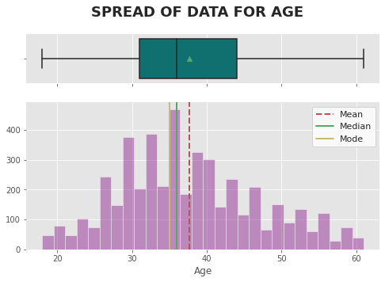

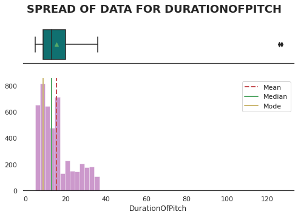

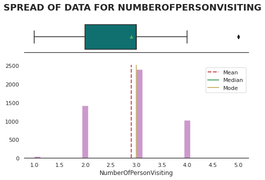

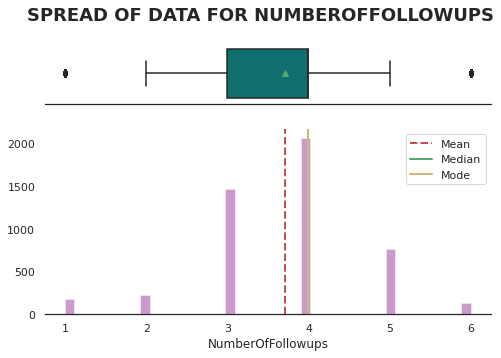

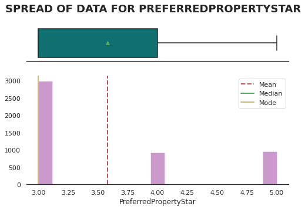

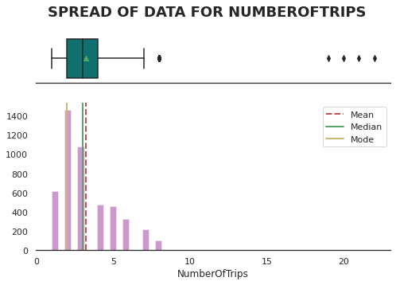

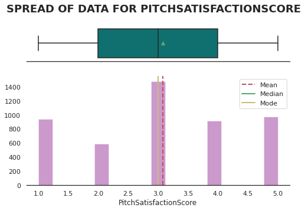

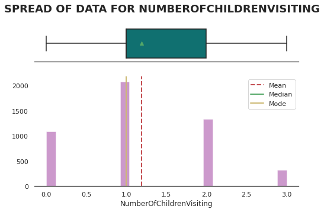

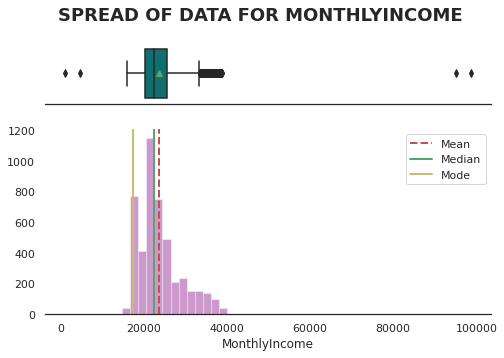

```python
#select all quantitative columns for checking the spread
list_col=  df_tour.select_dtypes(include='number').columns.to_list()
for i in range(len(list_col)):
    dist_box(df_tour[list_col[i]])
```

**Observations**

- Age is normally distrubted and doesn't have any outliers
- Duration of pitch is Right skewed with some outliers greater than 120 .Need to see if this are to be treated.
- Number of visitors is usually 3 with a outlier of 5.
- Average number of folows up are 4 with extreme of 6
- Number of trips is right skewed with some outliers where trips are greater than 17.
- Monthly income is Right skewed. and has some outlier as higher end.

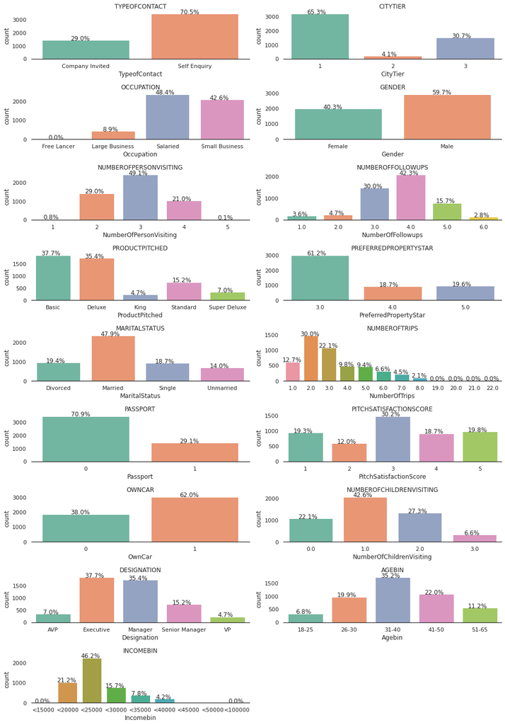

```python
# Making a list of all categorical variables

plt.figure(figsize=(14,20))

sns.set_theme(style="white")
cols=['TypeofContact', 'CityTier', 'Occupation', 'Gender',
        'NumberOfPersonVisiting', 'NumberOfFollowups', 'ProductPitched',
        'PreferredPropertyStar', 'MaritalStatus', 'NumberOfTrips',
        'Passport', 'PitchSatisfactionScore',
        'OwnCar', 'NumberOfChildrenVisiting',
        'Designation','Agebin','Incomebin']
for i, variable in enumerate(cols):
                     plt.subplot(9,2,i+1)
                     order = df_tour[variable].value_counts(ascending=False).index
                     #sns.set_palette(list_palette[i]) # to set the palette
                     sns.set_palette('Set2')
                     ax=sns.countplot(x=df_tour[variable], data=df_tour )
                     sns.despine(top=True,right=True,left=True) # to remove side line from graph
                     for p in ax.patches:
                           percentage = '{:.1f}%'.format(100 * p.get_height()/len(df_tour[variable]))
                           x = p.get_x() + p.get_width() / 2 - 0.05
                           y = p.get_y() + p.get_height()
                           plt.annotate(percentage, (x, y),ha='center')
                     plt.tight_layout()
                     plt.title(cols[i].upper())
```

**Observations**

- ~38 % customers are Executive, followed by 35% are managers.
- ~18% customers accepted product offered last time.
- ~ 62 % customer own car.
- ~29 % customers has a passport.
- ~ 65 % customers are from Tier 1 cities.
- ~ 61 % customers prefer 3 star property.
- ~ 48 % customers are married
- Basic package was pitched to ~ 38 % of customers and 35 % were pitched Deluxe package.
- 60 % customers are male.
- Occupation of ~ 49 % customer is salaried.
- 70.5 % customer self enquiried for the packages.
- Most of the customers travelled along with 3 people.
- Most of the customers take 2 trips per year but as seen previously there are some extreme values like 22.
- Most of the customers travelled with only one child.
- Most of the customers were followed up 4 times.
- Majority of customer monthly income is in 20000-25000 range.Most customer fall in 15000-30000 monthly income range.
- ~35% are in 31-40 Age group. Most customer are in 26-50 age range

### Bivariate & Multivariate Analysis

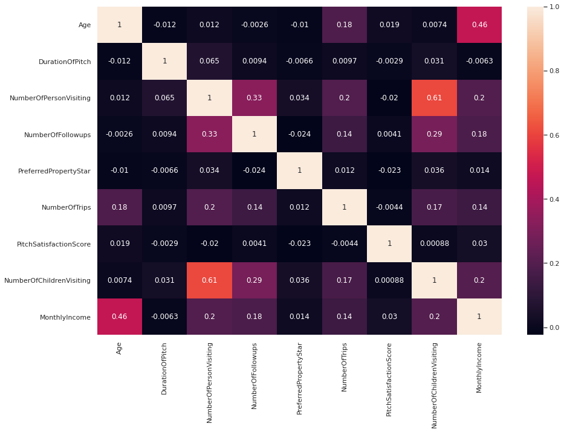

```python
sns.set_palette(sns.color_palette("Set2", 8))
plt.figure(figsize=(15,10))
sns.heatmap(df_tour.corr(),annot=True)
plt.show()
```

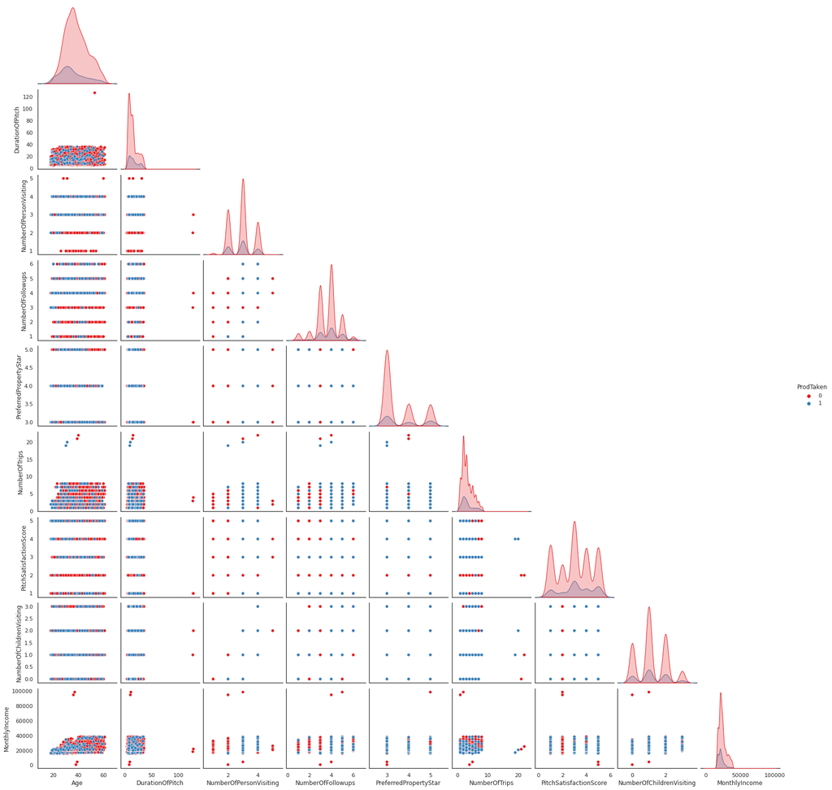

```python
sns.set_palette(sns.color_palette("Set1", 8))
sns.pairplot(df_tour, hue="ProdTaken",corner=True)
plt.show()
```

**Observations**

- Monthlyincome and Age has weak correlation
- Number of children visiting and number of person vsiting has correlation as expected.

## Numberof follow up and number of person vsiting has very weak correlation.

```python
### Function to plot distributions and Boxplots of customers
def plot(x,target='ProdTaken'):
    fig,axs = plt.subplots(2,2,figsize=(12,10))
    axs[0, 0].set_title(f'Distribution of {x} \n of a customer who had Not taken Product',fontsize=12,fontweight='bold')
    sns.distplot(df_tour[(df_tour[target] == 0)][x],ax=axs[0,0],color='teal')
    axs[0, 1].set_title(f"Distribution of {x}\n of a customer who had taken Product",fontsize=12,fontweight='bold')
    sns.distplot(df_tour[(df_tour[target] == 1)][x],ax=axs[0,1],color='orange')
    axs[1,0].set_title(f'Boxplot of {x} w.r.t Product taken',fontsize=12,fontweight='bold')

    line = plt.Line2D((.1,.9),(.5,.5), color='grey', linewidth=1.5,linestyle='--')
    fig.add_artist(line)

    sns.boxplot(df_tour[target],df_tour[x],ax=axs[1,0],palette='gist_rainbow',showmeans=True)
    axs[1,1].set_title(f'Boxplot of {x} w.r.t Product Taken - Without outliers',fontsize=12,fontweight='bold')
    sns.boxplot(df_tour[target],df_tour[x],ax=axs[1,1],showfliers=False,palette='gist_rainbow',showmeans=True) #turning off outliers from boxplot
    sns.despine(top=True,right=True,left=True) # to remove side line from graph
    plt.tight_layout(pad=4)
    plt.show()
```

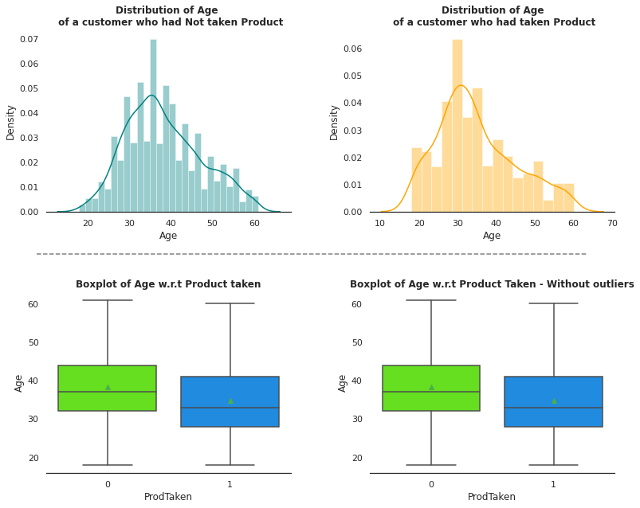

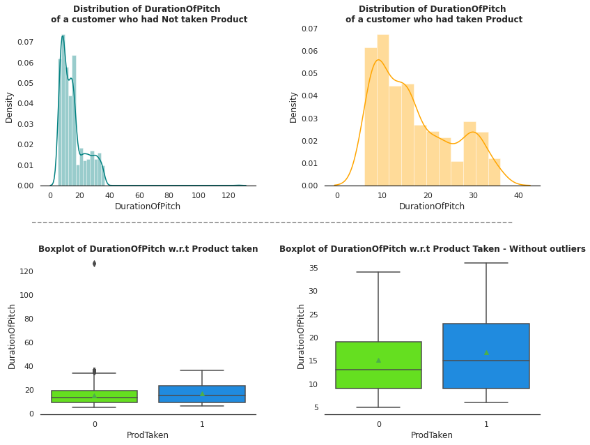

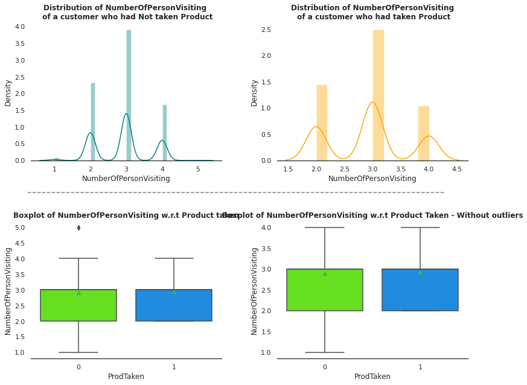

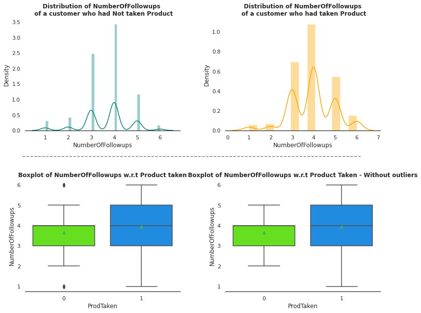

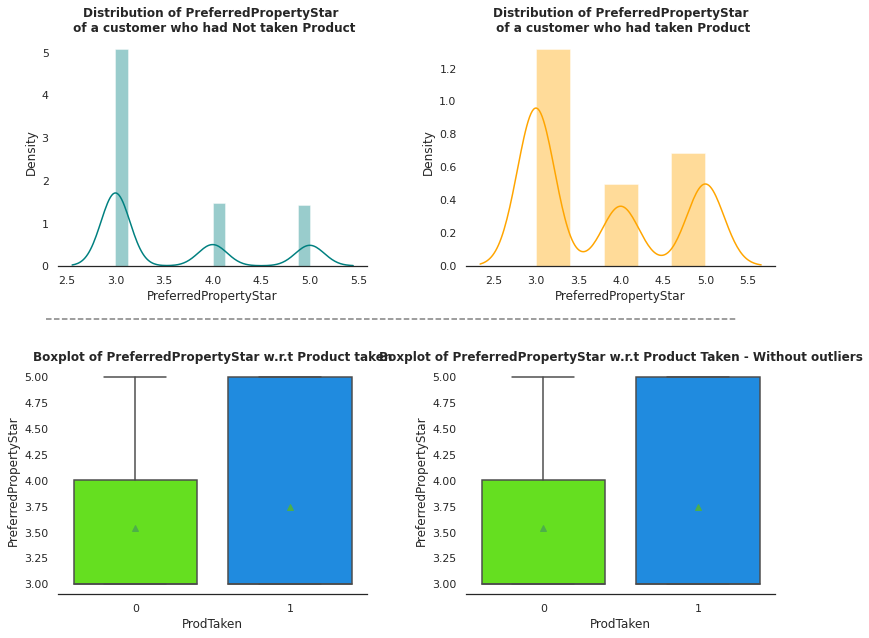

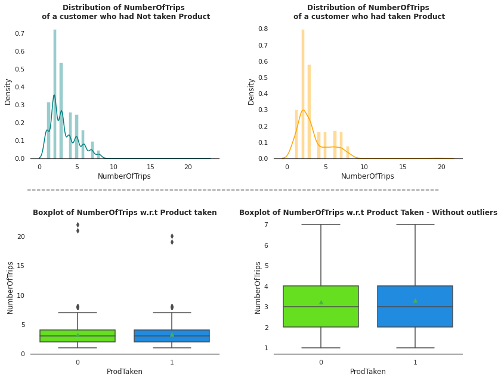

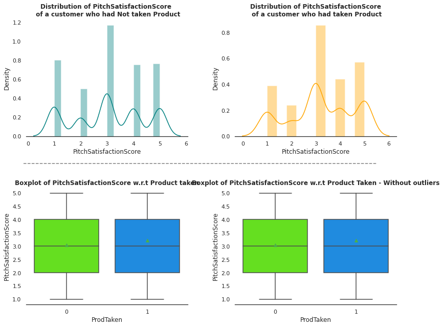

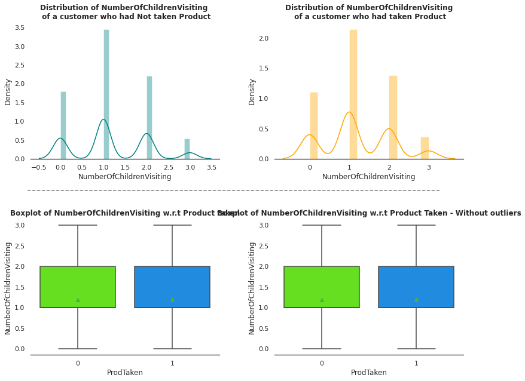

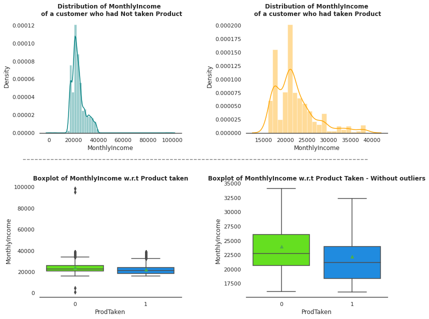

```python
#select all quantitative columns for checking the spread
#list_col=  ['Age','DurationOfPitch','MonthlyIncome']
list_col=df_tour.select_dtypes(include='number').columns.to_list()
#print(list_col)
#plt.figure(figsize=(14,23))
for j in range(len(list_col)):
   plot(list_col[j])
```

**Observation**

- Customers who purchased the product are mostly in age range of 28 -35
- Duration of pitch suprisingly for customer who purchased product where 10- 40 min. There are some outliers in duration of pitch for customers who didn't take the product
- Number of trips has some outliers like 17 -20.
- Monthly income has extreme outliers.Customers who purchased product are in earning on average 18000-23000 monthly

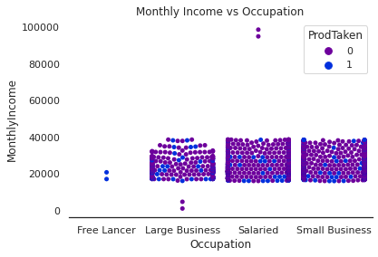

```python
sns.set_palette(sns.color_palette("nipy_spectral", 8))

sns.swarmplot(y='MonthlyIncome',x='Occupation',hue='ProdTaken',data=df_tour)
sns.despine(top=True,right=True,left=True) # to remove side line from graph
plt.title('Monthly Income vs Occupation')
```

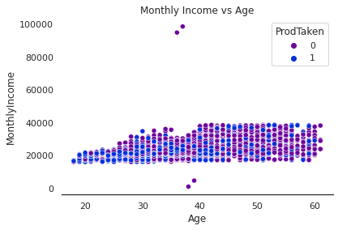

```python
sns.set_palette(sns.color_palette("nipy_spectral", 8))
sns.scatterplot(y='MonthlyIncome',x='Age',hue='ProdTaken',data=df_tour)
sns.despine(top=True,right=True,left=True) # to remove side line from graph
plt.title('Monthly Income vs Age')
```

## Missing value Detection and Treatment

```python
df_tour.isnull().sum()
```

```
ProdTaken                     0
Age                         226
TypeofContact                25
CityTier                      0
DurationOfPitch             251
Occupation                    0
Gender                        0
NumberOfPersonVisiting        0
NumberOfFollowups            45
ProductPitched                0
PreferredPropertyStar        26
MaritalStatus                 0
NumberOfTrips               140
Passport                      0
PitchSatisfactionScore        0
OwnCar                        0
NumberOfChildrenVisiting     66
Designation                   0
MonthlyIncome               233
Agebin                      240
Incomebin                   233
dtype: int64
```

#### Missing value Treatment Type of contact

```python
df_tour['TypeofContact'].value_counts()
```

```
Self Enquiry       3444
Company Invited    1419
Name: TypeofContact, dtype: int64
```

Highest ocurring value is `Self Inquiry`. We will impute the missing value for TypeofContact using the mode(highest occuring value) of the feature.

```python
df_tour['TypeofContact'].mode()

df_tour['TypeofContact']=df_tour['TypeofContact'].fillna('Self Enquiry')
```

```python
#Verify if there are null values
df_tour["TypeofContact"].isnull().sum()
```

```
0
```

#### Missing value Treatment number of followup.

```python
df_tour.groupby(["Gender",'ProductPitched'])["NumberOfFollowups"].median()

df_tour['NumberOfFollowups']=df_tour.groupby(["Gender",'ProductPitched'])["NumberOfFollowups"].apply(lambda x:x.fillna(x.median()))
```

#### Missing value Treatment PreferredPropertyStar

```python
#Look at few rows where values  is missing
df_tour[df_tour["PreferredPropertyStar"].isnull()]
```

|  | ProdTaken | Age | TypeofContact | CityTier | DurationOfPitch | Occupation | Gender | NumberOfPersonVisiting | NumberOfFollowups | ProductPitched | ... | MaritalStatus | NumberOfTrips | Passport | PitchSatisfactionScore | OwnCar | NumberOfChildrenVisiting | Designation | MonthlyIncome | Agebin | Incomebin |
| --- | --- | --- | --- | --- | --- | --- | --- | --- | --- | --- | --- | --- | --- | --- | --- | --- | --- | --- | --- | --- | --- |
| 38 | 0 | 36.00000 | Self Enquiry | 1 | 11.00000 | Salaried | Female | 2 | 4.00000 | Basic | ... | Divorced | 1.00000 | 1 | 2 | 1 | 0.00000 | Executive | 95000.00000 | 31-40 | <100000 |
| 2609 | 0 | 51.00000 | Self Enquiry | 1 | 18.00000 | Salaried | Female | 3 | 4.00000 | King | ... | Single | 5.00000 | 0 | 5 | 1 | 1.00000 | VP | 38604.00000 | 51-65 | <40000 |
| 2634 | 0 | 53.00000 | Self Enquiry | 1 | 7.00000 | Salaried | Male | 4 | 5.00000 | King | ... | Divorced | 2.00000 | 0 | 2 | 1 | 2.00000 | VP | 38677.00000 | 51-65 | <40000 |
| 3012 | 1 | 56.00000 | Self Enquiry | 1 | 9.00000 | Small Business | Male | 4 | 4.00000 | King | ... | Divorced | 7.00000 | 1 | 2 | 1 | 3.00000 | VP | 38537.00000 | 51-65 | <40000 |
| 3190 | 0 | 42.00000 | Company Invited | 1 | 14.00000 | Salaried | Female | 3 | 6.00000 | King | ... | Married | 3.00000 | 0 | 4 | 1 | 1.00000 | VP | 38651.00000 | 41-50 | <40000 |
| 3193 | 1 | 53.00000 | Self Enquiry | 3 | 9.00000 | Small Business | Female | 3 | 6.00000 | King | ... | Divorced | 3.00000 | 0 | 3 | 1 | 1.00000 | VP | 38523.00000 | 51-65 | <40000 |
| 3214 | 0 | 47.00000 | Self Enquiry | 1 | 7.00000 | Small Business | Male | 3 | 4.00000 | King | ... | Married | 2.00000 | 0 | 5 | 1 | 2.00000 | VP | 38305.00000 | 41-50 | <40000 |
| 3295 | 0 | 57.00000 | Self Enquiry | 1 | 11.00000 | Large Business | Female | 4 | 4.00000 | King | ... | Married | 6.00000 | 0 | 4 | 0 | 3.00000 | VP | 38621.00000 | 51-65 | <40000 |
| 3342 | 0 | 44.00000 | Self Enquiry | 1 | 10.00000 | Salaried | Male | 4 | 6.00000 | King | ... | Divorced | 5.00000 | 0 | 5 | 1 | 3.00000 | VP | 38418.00000 | 41-50 | <40000 |
| 3362 | 0 | 52.00000 | Company Invited | 3 | 16.00000 | Salaried | Male | 3 | 4.00000 | King | ... | Married | 6.00000 | 1 | 4 | 1 | 2.00000 | VP | 38525.00000 | 51-65 | <40000 |
| 3400 | 0 | 57.00000 | Self Enquiry | 2 | 15.00000 | Salaried | Male | 3 | 4.00000 | King | ... | Single | 8.00000 | 0 | 4 | 1 | 1.00000 | VP | 38395.00000 | 51-65 | <40000 |
| 3453 | 0 | 59.00000 | Self Enquiry | 1 | 7.00000 | Small Business | Female | 4 | 4.00000 | King | ... | Divorced | 5.00000 | 1 | 1 | 1 | 3.00000 | VP | 38379.00000 | 51-65 | <40000 |
| 3598 | 0 | 48.00000 | Self Enquiry | 2 | 33.00000 | Salaried | Female | 4 | 4.00000 | King | ... | Married | 5.00000 | 0 | 4 | 1 | 2.00000 | VP | 38336.00000 | 41-50 | <40000 |
| 3686 | 0 | 41.00000 | Self Enquiry | 3 | 14.00000 | Small Business | Male | 3 | 4.00000 | King | ... | Single | 3.00000 | 0 | 4 | 1 | 2.00000 | VP | 38511.00000 | 41-50 | <40000 |
| 3775 | 0 | 49.00000 | Self Enquiry | 1 | 17.00000 | Salaried | Male | 4 | 5.00000 | King | ... | Married | 6.00000 | 0 | 3 | 1 | 2.00000 | VP | 38343.00000 | 41-50 | <40000 |
| 3845 | 0 | 56.00000 | Self Enquiry | 2 | 33.00000 | Salaried | Male | 4 | 2.00000 | King | ... | Married | 6.00000 | 1 | 5 | 1 | 3.00000 | VP | 38314.00000 | 51-65 | <40000 |
| 4079 | 0 | 51.00000 | Self Enquiry | 1 | 18.00000 | Salaried | Female | 3 | 4.00000 | King | ... | Single | 5.00000 | 0 | 5 | 0 | 2.00000 | VP | 38604.00000 | 51-65 | <40000 |
| 4104 | 0 | 53.00000 | Self Enquiry | 1 | 7.00000 | Salaried | Male | 4 | 5.00000 | King | ... | Married | 2.00000 | 0 | 1 | 1 | 3.00000 | VP | 38677.00000 | 51-65 | <40000 |
| 4482 | 1 | 56.00000 | Self Enquiry | 1 | 9.00000 | Small Business | Male | 4 | 4.00000 | King | ... | Married | 7.00000 | 1 | 1 | 1 | 1.00000 | VP | 38537.00000 | 51-65 | <40000 |
| 4660 | 0 | 42.00000 | Company Invited | 1 | 14.00000 | Salaried | Female | 3 | 6.00000 | King | ... | Married | 3.00000 | 0 | 4 | 1 | 2.00000 | VP | 38651.00000 | 41-50 | <40000 |
| 4663 | 1 | 53.00000 | Self Enquiry | 3 | 9.00000 | Small Business | Female | 3 | 6.00000 | King | ... | Married | 3.00000 | 0 | 3 | 1 | 2.00000 | VP | 38523.00000 | 51-65 | <40000 |
| 4684 | 0 | 47.00000 | Self Enquiry | 1 | 7.00000 | Small Business | Male | 3 | 4.00000 | King | ... | Married | 2.00000 | 0 | 5 | 1 | 1.00000 | VP | 38305.00000 | 41-50 | <40000 |
| 4765 | 0 | 57.00000 | Self Enquiry | 1 | 11.00000 | Large Business | Female | 4 | 4.00000 | King | ... | Married | 6.00000 | 0 | 4 | 1 | 2.00000 | VP | 38621.00000 | 51-65 | <40000 |
| 4812 | 0 | 44.00000 | Self Enquiry | 1 | 10.00000 | Salaried | Male | 4 | 6.00000 | King | ... | Married | 5.00000 | 0 | 5 | 1 | 1.00000 | VP | 38418.00000 | 41-50 | <40000 |
| 4832 | 1 | 52.00000 | Company Invited | 1 | 35.00000 | Salaried | Male | 4 | 5.00000 | Deluxe | ... | Single | 5.00000 | 0 | 3 | 0 | 1.00000 | Manager | 38525.00000 | 51-65 | <40000 |
| 4870 | 1 | 57.00000 | Self Enquiry | 3 | 23.00000 | Salaried | Female | 4 | 4.00000 | Standard | ... | Single | 4.00000 | 1 | 5 | 1 | 3.00000 | Senior Manager | 38395.00000 | 51-65 | <40000 |

26 rows × 21 columns

Let see how can impute PreferredPropertyStar using designation of customer for more granularity

```python
df_tour['PreferredPropertyStar']=df_tour.groupby(["Designation"])["PreferredPropertyStar"].apply(lambda x:x.fillna(x.median()))

df_tour[df_tour["PreferredPropertyStar"].isnull()]
```

|  | ProdTaken | Age | TypeofContact | CityTier | DurationOfPitch | Occupation | Gender | NumberOfPersonVisiting | NumberOfFollowups | ProductPitched | ... | MaritalStatus | NumberOfTrips | Passport | PitchSatisfactionScore | OwnCar | NumberOfChildrenVisiting | Designation | MonthlyIncome | Agebin | Incomebin |
| --- | --- | --- | --- | --- | --- | --- | --- | --- | --- | --- | --- | --- | --- | --- | --- | --- | --- | --- | --- | --- | --- |

0 rows × 21 columns

#### Missing value Treatment Duration of pitch

Let see how can we impute Duration of pitch.In my opinion an important factor for how long sale person take times to market his sales pitch depends on Product which sale person is proposing , number of followup will also decide duration of pitch. Let verify this.

```python
df_tour.groupby(['ProductPitched','NumberOfFollowups'], as_index=False)["DurationOfPitch"].median()

# Impute missing Duration of pitch with median value
df_tour["DurationOfPitch"] = df_tour.groupby(["ProductPitched",'NumberOfFollowups'])["DurationOfPitch"].apply(
    lambda x: x.fillna(x.median())
)
```

```python
df_tour[df_tour["DurationOfPitch"].isnull()]

df_tour.isnull().sum()
```

```
ProdTaken                     0
Age                         226
TypeofContact                 0
CityTier                      0
DurationOfPitch               0
Occupation                    0
Gender                        0
NumberOfPersonVisiting        0
NumberOfFollowups             0
ProductPitched                0
PreferredPropertyStar         0
MaritalStatus                 0
NumberOfTrips               140
Passport                      0
PitchSatisfactionScore        0
OwnCar                        0
NumberOfChildrenVisiting     66
Designation                   0
MonthlyIncome               233
Agebin                      240
Incomebin                   233
dtype: int64
```

#### Missing value Treatment for NumberOfTrips

```python
df_tour.groupby(['MaritalStatus'])["NumberOfTrips"].median()
```

```
MaritalStatus
Divorced    3.00000
Married     3.00000
Single      2.00000
Unmarried   3.00000
Name: NumberOfTrips, dtype: float64
```

For more granularity imputing number of trips using martial status

```python
# Impute missing NumberOfTrips of pitch with median value
df_tour["NumberOfTrips"] = df_tour.groupby(["MaritalStatus"])["NumberOfTrips"].apply(
    lambda x: x.fillna(x.median())
)
```

#### Missing value Treatment NumberOfChildrenVisiting

```python
df_tour[df_tour["NumberOfChildrenVisiting"].isnull()].head(10)
```

|  | ProdTaken | Age | TypeofContact | CityTier | DurationOfPitch | Occupation | Gender | NumberOfPersonVisiting | NumberOfFollowups | ProductPitched | ... | MaritalStatus | NumberOfTrips | Passport | PitchSatisfactionScore | OwnCar | NumberOfChildrenVisiting | Designation | MonthlyIncome | Agebin | Incomebin |
| --- | --- | --- | --- | --- | --- | --- | --- | --- | --- | --- | --- | --- | --- | --- | --- | --- | --- | --- | --- | --- | --- |
| 165 | 0 | 50.00000 | Self Enquiry | 1 | 17.00000 | Salaried | Female | 2 | 3.00000 | King | ... | Single | 4.00000 | 0 | 5 | 1 | NaN | VP | 34926.00000 | 41-50 | <35000 |
| 190 | 0 | 52.00000 | Self Enquiry | 1 | 6.00000 | Salaried | Male | 3 | 4.00000 | King | ... | Divorced | 1.00000 | 0 | 2 | 1 | NaN | VP | 34999.00000 | 51-65 | <35000 |
| 568 | 1 | 55.00000 | Self Enquiry | 1 | 8.00000 | Small Business | Male | 3 | 3.00000 | King | ... | Divorced | 6.00000 | 1 | 2 | 1 | NaN | VP | 34859.00000 | 51-65 | <35000 |
| 746 | 0 | 41.00000 | Company Invited | 1 | 13.00000 | Salaried | Female | 2 | 5.00000 | King | ... | Married | 2.00000 | 0 | 4 | 1 | NaN | VP | 34973.00000 | 41-50 | <35000 |
| 749 | 1 | 52.00000 | Self Enquiry | 3 | 8.00000 | Small Business | Female | 2 | 5.00000 | King | ... | Divorced | 2.00000 | 0 | 3 | 1 | NaN | VP | 34845.00000 | 51-65 | <35000 |
| 851 | 0 | 56.00000 | Self Enquiry | 1 | 10.00000 | Large Business | Female | 3 | 3.00000 | King | ... | Married | 5.00000 | 0 | 4 | 0 | NaN | VP | 34943.00000 | 51-65 | <35000 |
| 898 | 0 | 43.00000 | Self Enquiry | 1 | 9.00000 | Salaried | Male | 3 | 5.00000 | King | ... | Divorced | 4.00000 | 0 | 5 | 1 | NaN | VP | 34740.00000 | 41-50 | <35000 |
| 918 | 0 | 51.00000 | Company Invited | 3 | 15.00000 | Salaried | Male | 2 | 3.00000 | King | ... | Married | 5.00000 | 1 | 4 | 1 | NaN | VP | 34847.00000 | 51-65 | <35000 |
| 956 | 0 | 56.00000 | Self Enquiry | 2 | 14.00000 | Salaried | Male | 2 | 3.00000 | King | ... | Single | 7.00000 | 0 | 4 | 1 | NaN | VP | 34717.00000 | 51-65 | <35000 |
| 1009 | 0 | 58.00000 | Self Enquiry | 1 | 6.00000 | Small Business | Female | 3 | 3.00000 | King | ... | Divorced | 4.00000 | 1 | 1 | 1 | NaN | VP | 34701.00000 | 51-65 | <35000 |

10 rows × 21 columns

Assuming children visited is missing because no children accompanied these customers so we will fill the missing values with 0

```python
# Impute missing NumberOfChildrenVisited with 0
df_tour['NumberOfChildrenVisiting']=df_tour['NumberOfChildrenVisiting'].fillna(0)
```

#### Missing value Treatment Age

Imputing age using designation,gender,Martial status would give more granularity

```python
df_tour[df_tour["Age"].isnull()].head(10)
```

|  | ProdTaken | Age | TypeofContact | CityTier | DurationOfPitch | Occupation | Gender | NumberOfPersonVisiting | NumberOfFollowups | ProductPitched | ... | MaritalStatus | NumberOfTrips | Passport | PitchSatisfactionScore | OwnCar | NumberOfChildrenVisiting | Designation | MonthlyIncome | Agebin | Incomebin |
| --- | --- | --- | --- | --- | --- | --- | --- | --- | --- | --- | --- | --- | --- | --- | --- | --- | --- | --- | --- | --- | --- |
| 4 | 0 | NaN | Self Enquiry | 1 | 8.00000 | Small Business | Male | 2 | 3.00000 | Basic | ... | Divorced | 1.00000 | 0 | 5 | 1 | 0.00000 | Executive | 18468.00000 | NaN | <20000 |
| 11 | 0 | NaN | Self Enquiry | 1 | 21.00000 | Salaried | Female | 2 | 4.00000 | Deluxe | ... | Single | 1.00000 | 1 | 3 | 0 | 0.00000 | Manager | NaN | NaN | NaN |
| 19 | 0 | NaN | Self Enquiry | 1 | 8.00000 | Salaried | Male | 2 | 3.00000 | Basic | ... | Single | 6.00000 | 1 | 4 | 0 | 1.00000 | Executive | NaN | NaN | NaN |
| 20 | 0 | NaN | Company Invited | 1 | 17.00000 | Salaried | Female | 3 | 2.00000 | Deluxe | ... | Married | 1.00000 | 0 | 3 | 1 | 2.00000 | Manager | NaN | NaN | NaN |
| 21 | 1 | NaN | Self Enquiry | 3 | 15.00000 | Salaried | Male | 2 | 4.00000 | Deluxe | ... | Single | 1.00000 | 0 | 2 | 0 | 0.00000 | Manager | 18407.00000 | NaN | <20000 |
| 26 | 1 | NaN | Company Invited | 1 | 22.00000 | Salaried | Female | 3 | 5.00000 | Basic | ... | Single | 2.00000 | 1 | 4 | 1 | 2.00000 | Executive | NaN | NaN | NaN |
| 44 | 0 | NaN | Company Invited | 1 | 6.00000 | Small Business | Female | 2 | 3.00000 | Deluxe | ... | Single | 2.00000 | 0 | 3 | 1 | 0.00000 | Manager | NaN | NaN | NaN |
| 51 | 1 | NaN | Self Enquiry | 1 | 11.00000 | Large Business | Male | 2 | 3.00000 | Basic | ... | Single | 2.00000 | 1 | 2 | 1 | 0.00000 | Executive | 18441.00000 | NaN | <20000 |
| 54 | 0 | NaN | Self Enquiry | 3 | 29.00000 | Small Business | Female | 2 | 4.00000 | Deluxe | ... | Divorced | 1.00000 | 1 | 2 | 1 | 0.00000 | Manager | NaN | NaN | NaN |
| 57 | 0 | NaN | Self Enquiry | 1 | 29.00000 | Small Business | Female | 1 | 3.00000 | Basic | ... | Divorced | 4.00000 | 1 | 4 | 1 | 0.00000 | Executive | NaN | NaN | NaN |

10 rows × 21 columns

```python
df_tour.groupby(["Designation", "Gender","MaritalStatus"])["Age"].median()

# Impute missing Age with median value
df_tour["Age"] = df_tour.groupby(["Designation", "Gender","MaritalStatus"])["Age"].apply(
    lambda x: x.fillna(x.median())
)
```

#### Missing value Treatment MonthlyIncome

For more granularity imputing on occupation,Designation,Gender

```python
df_tour.groupby(["Occupation",'Designation','Gender'])["MonthlyIncome"].median()
```

```
Occupation      Designation     Gender
Free Lancer     AVP             Female           NaN
                                Male             NaN
                Executive       Female           NaN
                                Male     18929.00000
                Manager         Female           NaN
                                Male             NaN
                Senior Manager  Female           NaN
                                Male             NaN
                VP              Female           NaN
                                Male             NaN
Large Business  AVP             Female   31872.00000
                                Male     29959.00000
                Executive       Female   20748.00000
                                Male     20743.50000
                Manager         Female   22198.50000
                                Male     21997.00000
                Senior Manager  Female   28266.00000
                                Male     26838.50000
                VP              Female   36583.00000
                                Male     36071.00000
Salaried        AVP             Female   31890.00000
                                Male     32505.50000
                Executive       Female   20748.00000
                                Male     20371.50000
                Manager         Female   22826.00000
                                Male     22873.50000
                Senior Manager  Female   26713.00000
                                Male     26052.50000
                VP              Female   35846.00000
                                Male     35971.00000
Small Business  AVP             Female   32171.50000
                                Male     32386.00000
                Executive       Female   20685.00000
                                Male     20582.00000
                Manager         Female   23071.00000
                                Male     22984.00000
                Senior Manager  Female   26383.50000
                                Male     26297.00000
                VP              Female   34845.00000
                                Male     35868.50000
Name: MonthlyIncome, dtype: float64
```

```python
df_tour["MonthlyIncome"]=df_tour.groupby(["Occupation",'Designation','Gender'])["MonthlyIncome"].apply(
    lambda x: x.fillna(x.median())
)
```

```python
df_tour.isnull().sum() #verify if all missing values have been treated
```

```
ProdTaken                     0
Age                           0
TypeofContact                 0
CityTier                      0
DurationOfPitch               0
Occupation                    0
Gender                        0
NumberOfPersonVisiting        0
NumberOfFollowups             0
ProductPitched                0
PreferredPropertyStar         0
MaritalStatus                 0
NumberOfTrips                 0
Passport                      0
PitchSatisfactionScore        0
OwnCar                        0
NumberOfChildrenVisiting      0
Designation                   0
MonthlyIncome                 0
Agebin                      240
Incomebin                   233
dtype: int64
```

#### Age

Age can be a vital factor in tourism, converting ages to bin to explore if there is any pattern

```python
df_tour.Age.describe()
```

```
count   4888.00000
mean      37.41356
std        9.16280
min       18.00000
25%       31.00000
50%       36.00000
75%       43.00000
max       61.00000
Name: Age, dtype: float64
```

```python
df_tour['Agebin'] = pd.cut(df_tour['Age'], bins = [15,25, 31, 40, 50, 70], labels = ['15-25','26-30', '31-40', '41-50', '51-70'])
```

```python
df_tour.Agebin.value_counts()
```

```
31-40    1894
41-50    1073
26-30    1025
51-70     549
15-25     347
Name: Agebin, dtype: int64
```

### Income

To understand customers segments derving new columns which will help us identify if customer in different income range

```python
df_tour.MonthlyIncome.describe()
```

```
count    4888.00000
mean    23543.85577
std      5267.65145
min      1000.00000
25%     20438.25000
50%     22393.00000
75%     25424.75000
max     98678.00000
Name: MonthlyIncome, dtype: float64
```

```python
df_tour['Incomebin'] = pd.cut(df_tour['MonthlyIncome'], bins = [0,15000,20000, 25000, 30000,35000,40000,45000,50000,100000], labels = ['<15000', '<20000', '<25000', '<30000','<35000','<40000','<45000','<50000','<100000'])
```

```python
df_tour.Incomebin.value_counts()
```

```
<25000     2490
<20000     1038
<30000      768
<35000      382
<40000      206
<15000        2
<100000       2
<45000        0
<50000        0
Name: Incomebin, dtype: int64
```

```python
df_tour.isnull().sum()
```

```
ProdTaken                   0
Age                         0
TypeofContact               0
CityTier                    0
DurationOfPitch             0
Occupation                  0
Gender                      0
NumberOfPersonVisiting      0
NumberOfFollowups           0
ProductPitched              0
PreferredPropertyStar       0
MaritalStatus               0
NumberOfTrips               0
Passport                    0
PitchSatisfactionScore      0
OwnCar                      0
NumberOfChildrenVisiting    0
Designation                 0
MonthlyIncome               0
Agebin                      0
Incomebin                   0
dtype: int64
```